# Analyzing the Relationship Between Healthcare Spending Structures and Mortality for High GDP-Per-Capita Countries in 2016

### Introduction

One of the most contentious topics in the US and around the world is how to provide healthcare to the people who need it. Countries tend to vary in what structure they choose for providing healthcare to their population. In particular, countries vary along how much of their GDP they spend on Healthcare, and what percentage of that spending comes from the government versus private individuals.

### Background

[GDP](https://www.bea.gov/resources/learning-center/what-to-know-gdp) stands for gross domestic product, and is a measure of the total economic output of a country. GDP per capita is measuring the GDP per person, and can be used as a measure of wealth between countries (a country producing \$55,000 worth of goods and services per person is more wealthy than a country producing $16,000 worth of goods and services per person). This wealth can be employed in different ways to impact the health of the people. The total amount of spending on healthcare by people in a country is known as its Current Health Expenditure (abbreviated CHE, or CHE per capita in the per person case). In order to find a metric of how much of a country's resources are spent in healthcare, we divide CHE by GDP and get [CHE as a % of GDP](https://www.who.int/data/gho/indicator-metadata-registry/imr-details/4950). GDP can be measured in any currency (here we will use US Dollars), and can be in direct currency or PPP-adjusted. [PPP](https://onlinelibrary.wiley.com/doi/pdf/10.1111/1467-9396.00394?casa_token=o7-xjBRs2L4AAAAA:Pumxbb7La2BszPDPP6_Ry7P2URNznGcZ3mpW7zX6hLbTRlKtLoLsdIYi6egb0omyBpGU035qw8M7JOeU) (Purchasing Power Parity) adjustment is an adjustment based on prices to more accurately measure currency in certain cases. See the Appendix for more details on PPP adjustments.

This spending on healthcare falls to two parties: governments and private individuals. There are four different means by which countries break down the spending. These are, in order from most private spending to most public spending: private insurance, mandatory insurance, a two-tiered government provided system, and a single payer government system. Under private insurance, private individuals select among companies (or a government plan) to secure insurance, or just pay costs out-of-pocket. Under an insurance mandate, there is a government mandate to secure insurance, but otherwise the structure is the same as private plans. Under a two-tier system, the government provides everyone with a base level of care, with private individuals able to purchase more coverage. Under a single payer system, the government is wholly responsible for care. See the [WHO website](https://www.who.int/), and more specifically the [WHO Data Tool](https://apps.who.int/nha/database/Select/Indicators/en) to query more detailed information on spending. The outcomes of these systems will be measured by mortality rates. A mortality rate in a population is the answer to the question "of every 1000 people in this given population, how many will not survive for one year?"

Previous studies are split on the issue of government spending and GDP influencing mortality rates. Older studies tend to draw little relationship between government spending and health outcomes (Health care spending as determinants of health outcomes), whereas newer studies claim that there is a decrease in mortality to caused by government spending, but only to infants and children ([Government health expenditures and health outcomes](https://onlinelibrary.wiley.com/doi/pdf/10.1002/hec.1157?casa_token=Sjz-iNerOCwAAAAA:JNcRfJLkrCSyaDczoE5QwERxTaON-aa7cHDfU_92pLrQMNfGYAvuEdLKVW7o-cDCgn4Jj88rdkVckgxq), [The relationship between health care expenditure and health outcomes](https://link.springer.com/article/10.1007/s10198-005-0336-8)). In this analysis, I want to measure the spending habits of countries with a high GDP-per-capita and see if there is a correlation between their Healthcare structures and their probability of death as infants, children, and adults.

Finding the most efficient way to structure healthcare is an important challenge to everyone. All of our lives are contingent on our health, and providing for the health of its people is of critical importance to any modern government. Finding the most efficient way to spend money to increase positive health outcomes can yield insight as to how each government can take on the challenge of maintaining the health of its population with limited resources.

### Research Questions

The research questions are the following:

- **Question 1**: What countries have a GDP-per-capita at or above the average?
- **Question 2**: How do different countries in this group vary in healthcare spending and health outcomes?
- **Question 3**: What is the relation between healthcare spending and healthcare outcomes?
- **Question 4**: What are the differences between the types of spending systems?

### Project Setup and Methodology

Question 1 is to determine which countries I include in this study. The reason I want to only study countries with a high GDP is because countries with lower GDPs tend to face categorically different problems. A country with an annual GDP-per-capita in the hundreds will have to focus on providing more basic forms of care for their people, like running water and electricity. This is a different challenge than a country with an annual GDP-per-capita in the tens of thousands, which will focus more on optimizing and advancing medical technology. A country with a low GDP-per-capita may also be forced to spend a high portion of their GDP on healthcare due to higher relative fixed costs compared to more developed economies. Because these challenges are so different, I believe that low GDP and high GDP countries warrant two different analyses, and in this analysis I have chosen to focus on finding an efficient way for high GDP-per-capita countries to spend their resources.

Question 2 shows how these countries approach healthcare and what the results of their strategies are. The data for question 2 is imported from the [WHO Data Tool](https://apps.who.int/nha/database/Select/Indicators/en). The data comes from all the countries in the data tool in the year 2016 (the most recent year for which all of the relevant statistics were availiable). This will show which countries spend more or less on healthcare and whether that money tends to come from public or private sources. It also has several other data fields which may be helpful in determining the specifics of how each country approaches healthcare spending. It will also be answered using data from [World Bank Infant Mortality](https://data.worldbank.org/indicator/SP.DYN.IMRT.IN?end=1974&most_recent_year_desc=false&start=1974), [UNICEF Child Mortality](https://data.unicef.org/resources/dataset/child-mortality/), and WHO Adult Mortality). These show the levels of infant, child, and adult mortality in the countries. The World Bank is an international charitible institution. UNICEF is a branch of the UN specifically devoted to the welfare of children.

Questions 3 and 4 use the results of questions 1 and 2 to attempt to make a prescriptive statement as to how a country with a developed economy should use its resources to emulate the most efficient healthcare systems. The goal will be to look for trends in spending patterns which correlate with lower mortality rates.

### Ethics

There are several stakeholders in this problem. The people receiving the healthcare are concerned with the quality of the healthcare. This will cause them to gauge possible solutions based on the quality of care that they provide. A different stakeholder is companies operating in the fields of biomedical technology, insurance, pharmaceuticals, etc. They will likely want to maintain their level of revenue, and may not want solutions which shift spending to the public sector or decrease operating output. Other stakeholders include politicians, some of whom vehemently fight for or against changing the current healthcare systems of their respective countries, and would want to use the results of such an analysis to strengthen their rhetorical positions.

It should be noted that healthcare outcomes are the products of complex sets of factors and drawing a 1-to-1 correlation between spending and outcome is inherently oversimplifying that complexity. Care must be taken not to extrapolate sweeping conclusions from this analysis for the purpose of changing policy without taking these other factors into account. [Policy can have a great impact](http://citeseerx.ist.psu.edu/viewdoc/download?doi=10.1.1.411.6359&rep=rep1&type=pdf) on health outcomes, and inaccurately assessing the efficiency of healthcare systems could lead to countries making sub-optimal plans on how to improve their healthcare infrastructure. Making mistakes in such a field costs people their good health or even their lives, thus care must be taken to ensure that the results accurately reflect the data.

### Importing Tools and Datasets

```python
import pandas as pd
from scipy import stats
import seaborn as sns
import matplotlib.pyplot as plt
import numpy as np
import matplotlib.cm as cm
import matplotlib.patches as mpatches
#Current Health Expenditures
CHE = pd.read_csv("data/2016 WHO Expenditure Stats.csv")
#Infant Mortalitiy
IMF = pd.read_csv("data/Infant Mortality (Per 1,000 Live Births).csv")
#Child Mortality
CMF = pd.read_csv("data/Child Mortality Rate.csv")
#Adult Mortality
AMF = pd.read_csv("data/WHO Adult Mortality.csv")
#GDP USD
USD = pd.read_csv("data/2016 USD GDP Per Capita.csv")
#Healthcare Types
HCT = pd.read_csv("data/Healthcare Systems.csv")
```

### Answering Research Question 1 - What countries have a GDP-per-capita at or above the average?

```python
average = USD["2016"].mean()
USD = USD[USD["2016"] >= average]
USD = USD.rename(columns = {'2016':'GDP Per Capita','Countries' : 'Country'})
GDP = USD.loc[:, ["Country", "GDP Per Capita"]]
GDP.head()
```

|  | Country | GDP Per Capita |
| --- | --- | --- |
| 38 | Seychelles | 14916 |
| 46 | Antigua and Barbuda | 15198 |
| 48 | Bahamas | 31588 |
| 49 | Barbados | 16900 |
| 53 | Canada | 41998 |

All of the countries with a GDP-per-capita at or above the global average are now in the dataset, 5 of which are listed above

### Answering Research Question 2 - How do different countries in this group vary in healthcare spending and health outcomes?

```python
CHE = CHE.drop(0)
CHE = CHE.drop(columns=['Unnamed: 2'])
percent = CHE[CHE["Indicators"] == "Current Health Expenditure (CHE) as % Gross Domestic Product (GDP)"]
total = CHE[CHE["Indicators"] == "Current Health Expenditure (CHE) per Capita in PPP"]
percent = percent.rename(columns = {'2016':'CHE as % of GDP','Countries' : 'Country'})
total = total.rename(columns = {'2016':'Total PPP-Adjusted Expenditure','Countries' : 'Country'})
CHE = total.merge(percent, on="Country")
CHE = CHE.drop(['Indicators_x', 'Indicators_y'],  axis=1)
```

This is the initial portion to question 2. The next step is to determine health outcomes. We will start with infant mortality

```python
CMF = CMF[CMF['Bounds'] == "Median"]
CMF = CMF.drop(columns=['Bounds'])
AMF = AMF[AMF.Dim1 == "Both sexes"]
AMF = AMF[AMF.Period == 2016]
AMF = AMF.drop(columns=['Period', 'Dim1'])
AMF = AMF.rename(columns = {'Location':'Country'})

#Mortality Frame
MF = IMF.merge(CMF)
MF = MF.merge(AMF)
MF.head()
```

|  | Country | Infant Mortality Rate | Child Mortality Rate | Adult Mortality Rate |
| --- | --- | --- | --- | --- |
| 0 | Afghanistan | 51.3 | 17.1323 | 245.20 |
| 1 | Angola | 55.6 | 30.3352 | 237.00 |
| 2 | Albania | 8.4 | 1.0492 | 96.41 |
| 3 | United Arab Emirates | 6.6 | 1.1303 | 73.95 |
| 4 | Argentina | 9.7 | 1.2055 | 111.40 |

The above frame shows the rate of mortality in 2016 across all countries in three phases: Infant (age 0-1), Child (age 1-4), and Adult (age 15-60).

```python
#Resetting Mortality Frame
MF = IMF.merge(CMF)
MF = MF.merge(AMF)
```

We now have a dataset containing the relevant mortality rates and one containing the health spending information. The next step is to see if there is a relationship between the two.

### Answering Research Question 3 - What is the relation between healthcare spending and healthcare outcomes?

```python
#Combined Frame
CF = GDP.merge(CHE, on="Country")
```

At this point, I have realized that finding the intersection of the GDP frame and the mortality frame leads to an incomplete picture. The reason for this is a difference in naming across the frames which leads to problems when merging. For example, if one frame has "United States" as a country and the other has "United States of America", merging on country will be a problem between them. I will have to fix this manually.

```python
GDPCountries = set(CF.Country)
MortalityCountries = set(MF.Country)
Difference = GDPCountries.symmetric_difference(MortalityCountries)
GDPCountries.intersection(Difference)
```

```
{'Andorra',
 'Bahamas',
 'Cook Islands',
 'Czech Republic',
 'Monaco',
 'Niue',
 'Palau',
 'Republic of Korea',
 'Saint Kitts and Nevis',
 'San Marino',
 'Slovakia',
 'United Kingdom'}
```

The list above shows the difference in the sets. I will now manually fix these differences. Note: Andorra, Bahamas, Cook Islands, Monaco, Niue, Palau, Saint Kitts and Nevis and San Marino do not have full data sets (most likely due to size, these are all tiny), and will thus be dropped from this analysis

```python
MF.loc[MF["Country"] == "Czechia", "Country"] = "Czech Republic"
MF.loc[MF["Country"] == "Korea, Rep.", "Country"] = "Republic of Korea"
MF.loc[MF["Country"] == "Slovak Republic", "Country"] = "Slovakia"
MF.loc[MF["Country"] == "United Kingdom of Great Britain and Northern Ireland", "Country"] = "United Kingdom"
```

```python
#Final Frame
FF = CF.merge(MF, on="Country")
```

Now we will analyze the data set by relating PPP-Adjusted expenditure to all 3 healthcare outcomes. We will start by visualizing the data.

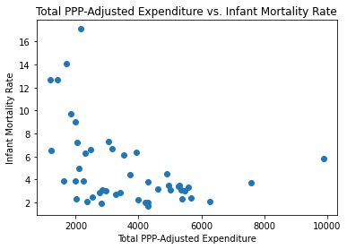

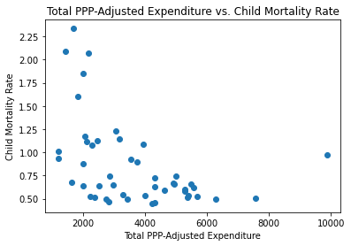

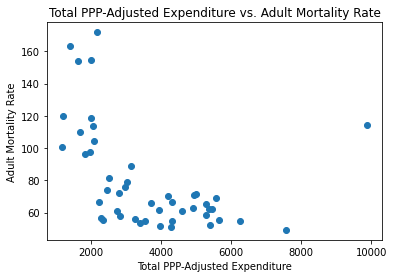

```python
#Scatter plot comparing infant moratality with total healthcare spending
plt.scatter(x = FF["Total PPP-Adjusted Expenditure"], y = FF["Infant Mortality Rate"])
plt.xlabel("Total PPP-Adjusted Expenditure")
plt.ylabel("Infant Mortality Rate")
plt.title("Total PPP-Adjusted Expenditure vs. Infant Mortality Rate")
plt.show()

#Scatter plot comparing child moratality with total healthcare spending
plt.scatter(x = FF["Total PPP-Adjusted Expenditure"], y = FF["Child Mortality Rate"])
plt.xlabel("Total PPP-Adjusted Expenditure")
plt.ylabel("Child Mortality Rate")
plt.title("Total PPP-Adjusted Expenditure vs. Child Mortality Rate")
plt.show()

#Scatter plot comparing adult moratality with total healthcare spending
plt.scatter(x = FF["Total PPP-Adjusted Expenditure"], y = FF["Adult Mortality Rate"])
plt.xlabel("Total PPP-Adjusted Expenditure")
plt.ylabel("Adult Mortality Rate")
plt.title("Total PPP-Adjusted Expenditure vs. Adult Mortality Rate")
plt.show()
```

It certainly looks like there is a correlation between increasing healthcare expenditure and decreasing mortality of all types. To make sure, lets run some Pearson's r correlation tests

```python
PPPInfant = stats.pearsonr(FF["Total PPP-Adjusted Expenditure"], FF["Infant Mortality Rate"])
PPPChild = stats.pearsonr(FF["Total PPP-Adjusted Expenditure"], FF["Child Mortality Rate"])
PPPAdult = stats.pearsonr(FF["Total PPP-Adjusted Expenditure"], FF["Adult Mortality Rate"])

print("Correlation between infant mortality rate and PPP-adjusted expenditure:", PPPInfant[0], "p-value:", PPPInfant[1])
print("Correlation between child mortality rate and PPP-adjusted expenditure:", PPPChild[0], "p-value:", PPPChild[1])
print("Correlation between adult mortality rate and PPP-adjusted expenditure:", PPPAdult[0], "p-value:", PPPAdult[1])
```

```
Correlation between infant mortality rate and PPP-adjusted expenditure: -0.4283111628474589 p-value: 0.0026689663227561088
Correlation between child mortality rate and PPP-adjusted expenditure: -0.4445979126311302 p-value: 0.0017423137762989209
Correlation between adult mortality rate and PPP-adjusted expenditure: -0.46316769217841924 p-value: 0.00104373358149742
```

Due to the low p-values of all three correlations, there appears to be a correlation between the total expenditures and health outcomes. Next we will check the correlation with healthcare spending as a percentage of GDP, starting with the visualization:

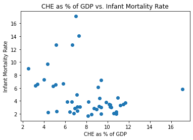

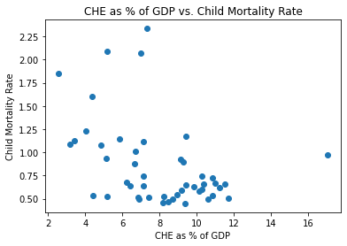

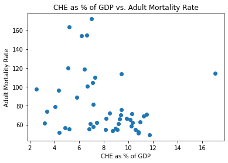

```python
#Scatter plot comparing infant moratality with CHE as % of GDP
plt.scatter(x = FF["CHE as % of GDP"], y = FF["Infant Mortality Rate"])
plt.xlabel("CHE as % of GDP")
plt.ylabel("Infant Mortality Rate")
plt.title("CHE as % of GDP vs. Infant Mortality Rate")
plt.show()

#Scatter plot comparing child moratality with CHE as % of GDP
plt.scatter(x = FF["CHE as % of GDP"], y = FF["Child Mortality Rate"])
plt.xlabel("CHE as % of GDP")
plt.ylabel("Child Mortality Rate")
plt.title("CHE as % of GDP vs. Child Mortality Rate")
plt.show()

#Scatter plot comparing adult moratality with CHE as % of GDP
plt.scatter(x = FF["CHE as % of GDP"], y = FF["Adult Mortality Rate"])
plt.xlabel("CHE as % of GDP")
plt.ylabel("Adult Mortality Rate")
plt.title("CHE as % of GDP vs. Adult Mortality Rate")
plt.show()
```

This seems to have a weaker correlation with mortality

```python
CHEInfant = stats.pearsonr(FF["CHE as % of GDP"], FF["Infant Mortality Rate"])
CHEChild = stats.pearsonr(FF["CHE as % of GDP"], FF["Child Mortality Rate"])
CHEAdult = stats.pearsonr(FF["CHE as % of GDP"], FF["Adult Mortality Rate"])

print("Correlation between infant mortality rate and CHE as % of GDP:", CHEInfant[0], "p-value:", CHEInfant[1])
print("Correlation between child mortality rate and CHE as % of GDP:", CHEChild[0], "p-value:", CHEChild[1])
print("Correlation between adult mortality rate and CHE as % of GDP:", CHEAdult[0], "p-value:", CHEAdult[1])
```

```
Correlation between infant mortality rate and CHE as % of GDP: -0.3421514177554379 p-value: 0.018570231218447565
Correlation between child mortality rate and CHE as % of GDP: -0.4079469239587231 p-value: 0.004421481008883813
Correlation between adult mortality rate and CHE as % of GDP: -0.23262710499930062 p-value: 0.11559383579527392
```

The p-values seem to indicate that the child and infant mortality rates are inversely correlated with CHE as % of GDP, but not adult mortality rates. This question was originally meant to see if there is an ideal spending number or percentage that countries should push for in their healthcare spending. The inverse correlation between spending and mortality combined with the shape of the scatter plots makes this point difficult to answer without drastically increasing the size of this analysis (e.g. including data to calculate the opportunity cost in economic output per dollar spent on healthcare).

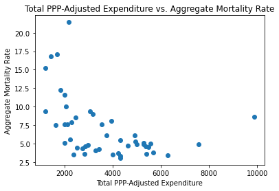

```python
aggregateMortality = FF["Infant Mortality Rate"] + (FF["Child Mortality Rate"]/4) + (FF["Adult Mortality Rate"]/45)
plt.scatter(x = FF["Total PPP-Adjusted Expenditure"], y = aggregateMortality)
plt.xlabel("Total PPP-Adjusted Expenditure")
plt.ylabel("Aggregate Mortality Rate")
plt.title("Total PPP-Adjusted Expenditure vs. Aggregate Mortality Rate")
plt.show()
```

Above is the aggregated mortality rate measured against total expenditure. To get a better understanding of how the countries with the lowest mortality rates function, lets limit to a rate of 10 or below

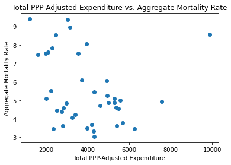

```python
plt.scatter(x = FF["Total PPP-Adjusted Expenditure"][aggregateMortality < 10], y = aggregateMortality[aggregateMortality < 10])
plt.xlabel("Total PPP-Adjusted Expenditure")
plt.ylabel("Aggregate Mortality Rate")
plt.title("Total PPP-Adjusted Expenditure vs. Aggregate Mortality Rate")
plt.show()
```

It is evident from this graph that there is very little correlation between the healthcare expenditure of the lowest mortality rate countries and their rates themselves. Most cluster between 2000-6000 in PPP adjusted expenditure, but there is hardly a one-to-one correlation between spending and outcomes at this level. Let's confirm this with a statistical test.

```python
lowestMortality = stats.pearsonr(FF["Total PPP-Adjusted Expenditure"][aggregateMortality < 10], aggregateMortality[aggregateMortality < 10])
lowestMortality
```

```
(-0.22764422092485256, 0.1577378819650455)
```

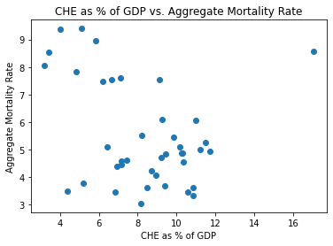

```python
plt.scatter(x = FF["CHE as % of GDP"][aggregateMortality < 10], y = aggregateMortality[aggregateMortality < 10])
plt.xlabel("CHE as % of GDP")
plt.ylabel("Aggregate Mortality Rate")
plt.title("CHE as % of GDP vs. Aggregate Mortality Rate")
plt.show()
```

```python
lowestMortalityPercent = stats.pearsonr(FF["CHE as % of GDP"][aggregateMortality < 10], aggregateMortality[aggregateMortality < 10])
lowestMortalityPercent
```

```
(-0.2996956502051716, 0.060274610256757524)
```

Here we have our answer to question 3, but it appears that the pure level of spending cannot explain differences in quality of outcomes for these countries. Thus, the search for an ideal rate is, at this point, inconclusive other than saying "most countries with the highest levels of positive outcomes range between 4-12% of GDP as CHE and 2000-6000 PPP-adjusted net spending on healthcare." One would think that the ideal setup for a high-GDP government would be to sit at the low end of this spectrum, as the marginal utility per dollar spent on healthcare seems to diminish above that level, but without a convincing model of exactly how spending affects healthcare outcomes, this conclusion is rather unhelpful. The more important question at this point is "now that we know the general correlation between spending and outcomes, at least in terms of mortality, is there a significant difference in the qualitative manner in which that spending occurs which impacts outcomes as well?" Clearly, isolating healthcare outcomes to exclusively the quantity of spending is overly reductive, and hopefully expanding the analysis a the second dimension of the manner of spending sheds some more light on the influence of spending patterns. To this end, I will conclude this analysis with a breakdown of spending systems and their varying rates of efficiency.

### Answering Research Question 4 - What are the differences between the types of spending systems?

Analyzing the healthcare systems of different countries in this range requires a base knowledge of healthcare systems. The following dataframe contains the list of countries with some degree of universal healthcare. This ranges from single payer, in which the government pays for everything, to two tier, in which there is a base level of coverage which is upgradable by high-income individuals, to an insurance mandante, which is a penalty for not getting insured.

```python
FinalCountries = set(FF.Country)
HealthcareCountries = set(HCT.Country)
Multis = FinalCountries.symmetric_difference(HealthcareCountries)
addingCol = ["Private"] * (len(Multis))
dualCs = []
for ctr in Multis:
    dualCs.append(ctr)
concatFrame = pd.DataFrame({'Country': dualCs, 'System Type': addingCol})
for ctry in Multis:
    changer = HCT.loc[HCT['Country'] == ctry, "System Type"].index
    HCT.drop(changer)
finalMergeFrame = pd.concat([HCT, concatFrame])
HFF = FF.merge(finalMergeFrame, on="Country")
```

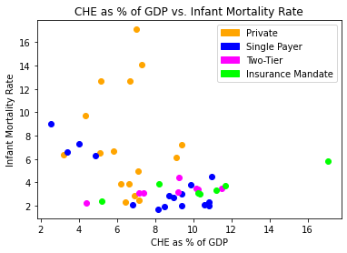

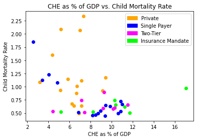

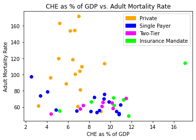

```python
x = "CHE as % of GDP"
y = "Infant Mortality Rate"
measuring = "System Type"
along = "Country"
types = ["Private","Single Payer","Two-Tier", "Insurance Mandate"]
colors = ["orange", "blue", "magenta","lime"]
plt.title("CHE as % of GDP vs. Adult Mortality Rate")
orange_patch = mpatches.Patch(color='orange', label='Private')
blue_patch = mpatches.Patch(color='blue', label='Single Payer')
pink_patch = mpatches.Patch(color='magenta', label='Two-Tier')
green_patch = mpatches.Patch(color='lime', label='Insurance Mandate')
lColors = [orange_patch, blue_patch, pink_patch, green_patch]

for i in [0,1,2,3]:
    for cnt in HFF.loc[HFF[measuring] == types[i], along]:
        plt.scatter(HFF.loc[HFF.Country == cnt, x], HFF.loc[HFF.Country == cnt, y], color=colors[i])
plt.xlabel("CHE as % of GDP")
plt.ylabel("Infant Mortality Rate")
plt.title("CHE as % of GDP vs. Infant Mortality Rate")
plt.legend(lColors, types)
plt.show()

y = "Child Mortality Rate"

for i in [0,1,2,3]:
    for cnt in HFF.loc[HFF[measuring] == types[i], along]:
        plt.scatter(HFF.loc[HFF.Country == cnt, x], HFF.loc[HFF.Country == cnt, y], color=colors[i])
plt.xlabel("CHE as % of GDP")
plt.ylabel("Child Mortality Rate")
plt.title("CHE as % of GDP vs. Child Mortality Rate")
plt.legend(lColors, types)
plt.show()

y = "Adult Mortality Rate"

for i in [0,1,2,3]:
    for cnt in HFF.loc[HFF[measuring] == types[i], along]:
        plt.scatter(HFF.loc[HFF.Country == cnt, x], HFF.loc[HFF.Country == cnt, y], color=colors[i])
plt.xlabel("CHE as % of GDP")
plt.ylabel("Adult Mortality Rate")
plt.title("CHE as % of GDP vs. Adult Mortality Rate")
plt.legend(lColors, types)
plt.show()
```

Above shows the CHE as a % of GDP broken down by mortality rate and system type. Orange is private, green is insurance mandated, pink is two-tier, and blue is single payer. Below is the same breakdown, but with total CHE spending instead of CHE as a proportion of GDP

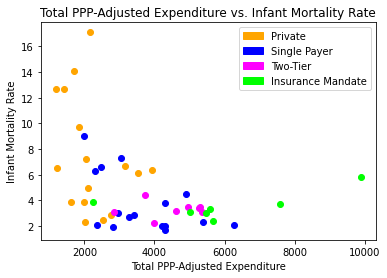

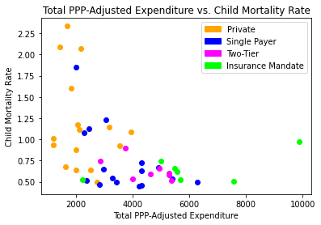

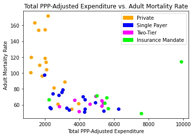

```python
x = "Total PPP-Adjusted Expenditure"
y = "Infant Mortality Rate"
measuring = "System Type"
along = "Country"
types = ["Private","Single Payer","Two-Tier", "Insurance Mandate"]
colors = ["orange", "blue", "magenta","lime"]
orange_patch = mpatches.Patch(color='orange', label='Private')
blue_patch = mpatches.Patch(color='blue', label='Single Payer')
pink_patch = mpatches.Patch(color='magenta', label='Two-Tier')
green_patch = mpatches.Patch(color='lime', label='Insurance Mandate')
lColors = [orange_patch, blue_patch, pink_patch, green_patch]

for i in [0,1,2,3]:
    for cnt in HFF.loc[HFF[measuring] == types[i], along]:
        plt.scatter(HFF.loc[HFF.Country == cnt, x], HFF.loc[HFF.Country == cnt, y], color=colors[i])
plt.xlabel(x)
plt.ylabel(y)
title = x+" vs. "+y
plt.title(title)
plt.legend(lColors, types)
plt.show()

x = "Total PPP-Adjusted Expenditure"
y = "Child Mortality Rate"
measuring = "System Type"
along = "Country"
types = ["Private","Single Payer","Two-Tier", "Insurance Mandate"]
colors = ["orange", "blue", "magenta","lime"]

for i in [0,1,2,3]:
    for cnt in HFF.loc[HFF[measuring] == types[i], along]:
        plt.scatter(HFF.loc[HFF.Country == cnt, x], HFF.loc[HFF.Country == cnt, y], color=colors[i])
plt.xlabel(x)
plt.ylabel(y)
title = x+" vs. "+y
plt.title(title)
plt.legend(lColors, types)
plt.show()

x = "Total PPP-Adjusted Expenditure"
y = "Adult Mortality Rate"
measuring = "System Type"
along = "Country"
types = ["Private","Single Payer","Two-Tier", "Insurance Mandate"]
colors = ["orange", "blue", "magenta","lime"]

for i in [0,1,2,3]:
    for cnt in HFF.loc[HFF[measuring] == types[i], along]:
        plt.scatter(HFF.loc[HFF.Country == cnt, x], HFF.loc[HFF.Country == cnt, y], color=colors[i])
plt.xlabel(x)
plt.ylabel(y)
title = x+" vs. "+y
plt.title(title)
plt.legend(lColors, types)
plt.show()
```

This appears to show that countries using a truly private system have a lower overall GDP than the other comparable countries, and seems to suggest that wealthier countries using a private system would instead opt for an insurance mandate. The following is a breakdown of the the relative GDPs of these countries

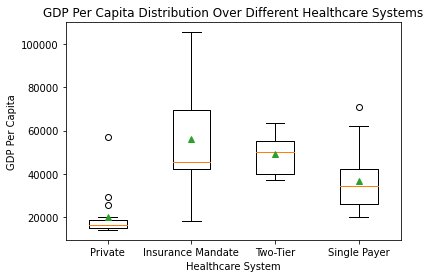

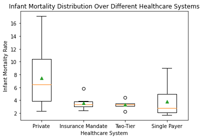

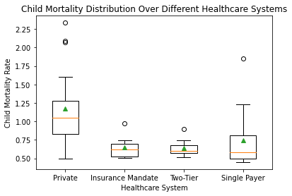

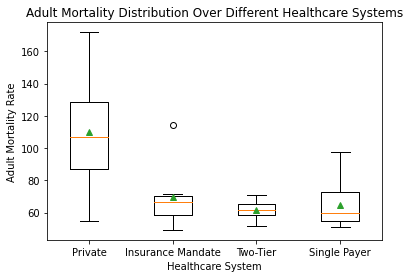

```python
Privates = HFF[HFF["System Type"] == "Private"]
InsuranceMandates = HFF[HFF["System Type"] == "Insurance Mandate"]
TwoTiers = HFF[HFF["System Type"] == "Two-Tier"]
Singlepayers = HFF[HFF["System Type"] == "Single Payer"]
PrivatesGDPs = Privates["GDP Per Capita"]
InsuranceMandatesGDPs = InsuranceMandates["GDP Per Capita"]
TwoTiersGDPs = TwoTiers["GDP Per Capita"]
SinglepayersGDPs = Singlepayers["GDP Per Capita"]
GDPs = [PrivatesGDPs, InsuranceMandatesGDPs, TwoTiersGDPs, SinglepayersGDPs]
plt.boxplot(GDPs, showmeans=True)
plt.title("GDP Per Capita Distribution Over Different Healthcare Systems")
plt.xlabel("Healthcare System")
plt.ylabel("GDP Per Capita")
plt.xticks([1, 2, 3, 4], ["Private", "Insurance Mandate", "Two-Tier", "Single Payer"])
plt.show()

Privates = HFF[HFF["System Type"] == "Private"]
InsuranceMandates = HFF[HFF["System Type"] == "Insurance Mandate"]
TwoTiers = HFF[HFF["System Type"] == "Two-Tier"]
Singlepayers = HFF[HFF["System Type"] == "Single Payer"]
PrivatesMTRs = Privates["Infant Mortality Rate"]
InsuranceMandatesMTRs = InsuranceMandates["Infant Mortality Rate"]
TwoTiersMTRs = TwoTiers["Infant Mortality Rate"]
SinglepayersMTRs = Singlepayers["Infant Mortality Rate"]
GDPs = [PrivatesMTRs, InsuranceMandatesMTRs, TwoTiersMTRs, SinglepayersMTRs]
plt.boxplot(GDPs, showmeans=True)
plt.title("Infant Mortality Distribution Over Different Healthcare Systems")
plt.xlabel("Healthcare System")
plt.ylabel("Infant Mortality Rate")
plt.xticks([1, 2, 3, 4], ["Private", "Insurance Mandate", "Two-Tier", "Single Payer"])
plt.show()

Privates = HFF[HFF["System Type"] == "Private"]
InsuranceMandates = HFF[HFF["System Type"] == "Insurance Mandate"]
TwoTiers = HFF[HFF["System Type"] == "Two-Tier"]
Singlepayers = HFF[HFF["System Type"] == "Single Payer"]
PrivatesMTRs = Privates["Child Mortality Rate"]
InsuranceMandatesMTRs = InsuranceMandates["Child Mortality Rate"]
TwoTiersMTRs = TwoTiers["Child Mortality Rate"]
SinglepayersMTRs = Singlepayers["Child Mortality Rate"]
GDPs = [PrivatesMTRs, InsuranceMandatesMTRs, TwoTiersMTRs, SinglepayersMTRs]
plt.boxplot(GDPs, showmeans=True)
plt.title("Child Mortality Distribution Over Different Healthcare Systems")
plt.xlabel("Healthcare System")
plt.ylabel("Child Mortality Rate")
plt.xticks([1, 2, 3, 4], ["Private", "Insurance Mandate", "Two-Tier", "Single Payer"])
plt.show()

Privates = HFF[HFF["System Type"] == "Private"]
InsuranceMandates = HFF[HFF["System Type"] == "Insurance Mandate"]
TwoTiers = HFF[HFF["System Type"] == "Two-Tier"]
Singlepayers = HFF[HFF["System Type"] == "Single Payer"]
PrivatesMTRs = Privates["Adult Mortality Rate"]
InsuranceMandatesMTRs = InsuranceMandates["Adult Mortality Rate"]
TwoTiersMTRs = TwoTiers["Adult Mortality Rate"]
SinglepayersMTRs = Singlepayers["Adult Mortality Rate"]
GDPs = [PrivatesMTRs, InsuranceMandatesMTRs, TwoTiersMTRs, SinglepayersMTRs]
plt.boxplot(GDPs, showmeans=True)
plt.title("Adult Mortality Distribution Over Different Healthcare Systems")
plt.xlabel("Healthcare System")
plt.ylabel("Adult Mortality Rate")
plt.xticks([1, 2, 3, 4], ["Private", "Insurance Mandate", "Two-Tier", "Single Payer"])
plt.show()
```

The above graphs show the GDP per capita and mortality rates for each healthcare system, with orange lines representing the median and green triangles representing means. Looking at the first graph, it does appear that there are significant differences in the levels of GDP for each type of system. To test this, we will use an ANOVA test:

```python
pvalue = stats.f_oneway(PrivatesGDPs, InsuranceMandatesGDPs, TwoTiersGDPs, SinglepayersGDPs).pvalue
print("ANOVA p-value:", float(pvalue))
```

```
ANOVA p-value: 7.724970605433573e-06
```

Due to the low p-value, it seems that the difference between the means is statistically significant, seemingly justifying the previous conclusion that multi-payer systems are phased out into (at least) insurance mandates as countries develop their economies. Now lets try to visualize outcomes of these systems. The most striking difference is between single payer and non-universal (private) systems, but there is a grey area when it comes to two-tier and insurance mandated systems. First, we will measure the healthcare outcomes of each type.

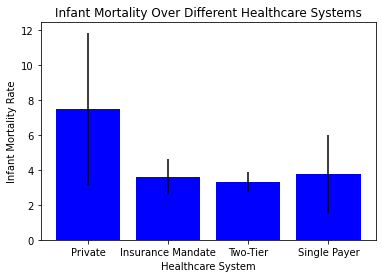

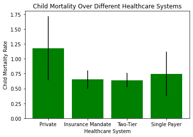

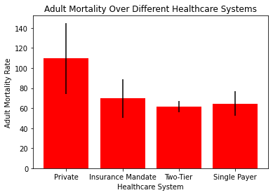

```python
PrivatesInfant = Privates["Infant Mortality Rate"]
PrivatesChild = Privates["Child Mortality Rate"]
PrivatesAdult = Privates["Adult Mortality Rate"]

InsuranceMandatesInfant = InsuranceMandates["Infant Mortality Rate"]
InsuranceMandatesChild = InsuranceMandates["Child Mortality Rate"]
InsuranceMandatesAdult = InsuranceMandates["Adult Mortality Rate"]

TwoTiersInfant = TwoTiers["Infant Mortality Rate"]
TwoTiersChild = TwoTiers["Child Mortality Rate"]
TwoTiersAdult = TwoTiers["Adult Mortality Rate"]

SinglepayersInfant = Singlepayers["Infant Mortality Rate"]
SinglepayersChild = Singlepayers["Child Mortality Rate"]
SinglepayersAdult = Singlepayers["Adult Mortality Rate"]

pinfant = PrivatesInfant.mean()
pchild = PrivatesChild.mean()
padult = PrivatesAdult.mean()

iminfant = InsuranceMandatesInfant.mean()
imchild = InsuranceMandatesChild.mean()
imadult = InsuranceMandatesAdult.mean()

ttinfant = TwoTiersInfant.mean()
ttchild = TwoTiersChild.mean()
ttadult = TwoTiersAdult.mean()

spinfant = SinglepayersInfant.mean()
spchild = SinglepayersChild.mean()
spadult = SinglepayersAdult.mean()

x = ["Private", "Insurance Mandate", "Two-Tier", "Single Payer"]
x_pos = [i for i, _ in enumerate(x)]
infantAverages = [pinfant, iminfant, ttinfant, spinfant]
childAverages = [pchild, imchild, ttchild, spchild]
adultAverages = [padult, imadult, ttadult, spadult]
Ivar = [np.std(PrivatesInfant), np.std(InsuranceMandatesInfant), np.std(TwoTiersInfant), np.std(SinglepayersInfant)]
Cvar = [np.std(PrivatesChild), np.std(InsuranceMandatesChild), np.std(TwoTiersChild), np.std(SinglepayersChild)]
Avar = [np.std(PrivatesAdult), np.std(InsuranceMandatesAdult), np.std(TwoTiersAdult), np.std(SinglepayersAdult)]


plt.bar(x_pos, infantAverages, color="blue", yerr=Ivar)
plt.xticks(x_pos, x)
plt.title("Infant Mortality Over Different Healthcare Systems")
plt.xlabel("Healthcare System")
plt.ylabel("Infant Mortality Rate")
plt.show()

plt.bar(x_pos, childAverages, color="green", yerr=Cvar)
plt.xticks(x_pos, x)
plt.title("Child Mortality Over Different Healthcare Systems")
plt.xlabel("Healthcare System")
plt.ylabel("Child Mortality Rate")
plt.show()

plt.bar(x_pos, adultAverages, color="red", yerr=Avar)
plt.xticks(x_pos, x)
plt.title("Adult Mortality Over Different Healthcare Systems")
plt.xlabel("Healthcare System")
plt.ylabel("Adult Mortality Rate")

plt.show()
```

These bar charts show the average mortality in each category for each system, with error bars showing standard deviation. These seem to show a difference between private systems and other types of systems. This may be accounted for by the previously established trends of private systems being endorsed by lower GDP per capita countries, lower total spending being correlated with worse outcomes, and lower GDP per capita being a cause of lower total spending.

There is one more argument I would like to go through to flesh out our understanding of healthcare efficiency. This relies on the economic concept of monopsony. Monopsony is a situation with many sellers and only one buyer (the inverse of a monopoly). Under a monopsony, the buyer has all of the power, and is able to negotiate low prices on account of controlling the entirety of demand in the supply/demand relationship. In a single payer system, the sole payer (the government) can negotiate much more aggressively with medical firms than any one individual due to controlling the whole demand for medical products. This, in theory, leads to lower prices, which should yield greater returns per dollar spent than an individual negotiating with a private company, thus increasing overall health outcomes in these countries. To test whether this theoretical difference currently bears out in the data, we will measure single payer systems against all other types of systems.

```python
SinglePayers = []
for x in HFF["System Type"]:
    SinglePayers.append(x=="Single Payer")
HFF.insert(7, "Single Payer?", SinglePayers, True)
```

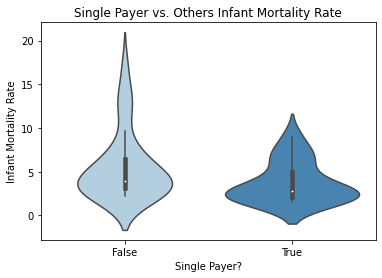

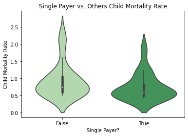

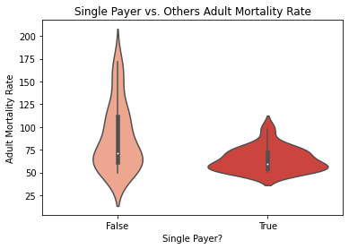

```python
violin = sns.violinplot(
            y = "Infant Mortality Rate",
            x = "Single Payer?",
            data = HFF,
            palette = "Blues",
            split = True,
            )
plt.title("Single Payer vs. Others Infant Mortality Rate")
plt.show()

violin = sns.violinplot(
            y = "Child Mortality Rate",
            x = "Single Payer?",
            data = HFF,
            palette = "Greens",
            split = True,
            )
plt.title("Single Payer vs. Others Child Mortality Rate")
plt.show()

violin = sns.violinplot(
            y = "Adult Mortality Rate",
            x = "Single Payer?",
            data = HFF,
            palette = "Reds",
            split = True,
            )
plt.title("Single Payer vs. Others Adult Mortality Rate")
plt.show()
```

It seems like there is some difference in distributions of mortality rates from single payers to other types of systems, but not a significant one. To test this, we will use a t-test.

```python
nonI = []
for x in PrivatesInfant:
    nonI.append(x)
for x in InsuranceMandatesInfant:
    nonI.append(x)
for x in TwoTiersInfant:
    nonI.append(x)

nonC = []
for x in PrivatesChild:
    nonC.append(x)
for x in InsuranceMandatesChild:
    nonC.append(x)
for x in TwoTiersChild:
    nonC.append(x)

nonA = []
for x in PrivatesAdult:
    nonA.append(x)
for x in InsuranceMandatesAdult:
    nonA.append(x)
for x in TwoTiersAdult:
    nonA.append(x)

pI = stats.ttest_ind(nonI, SinglepayersInfant).pvalue
pC = stats.ttest_ind(nonC, SinglepayersChild).pvalue
pA = stats.ttest_ind(nonA, SinglepayersAdult).pvalue

print("P value between single payer and other systems in infant mortality:", pI)
print("P value between single payer and other systems in child mortality:", pC)
print("P value between single payer and other systems in adult mortality:", pA)
```

```
P value between single payer and other systems in infant mortality: 0.09901908382699265
P value between single payer and other systems in child mortality: 0.2209304961851664
P value between single payer and other systems in adult mortality: 0.014183846238316873
```

As the violin graphs seem to show, there is not a significant difference between infant or child mortality across single payer vs non-single payer systems. The surprise here is that the difference between single payer and non single payer for adult mortality does appear to be statistically significant.

### Discussion

It appears that, while there is a correlation between increasing healthcare spending and decreasing mortality across the board, the data is not fine-tuned enough to make a strong prescriptive statement about one optimal spending pattern to maximize outcomes, only the general trends observed at the end of question 3. This study does not seem to show a significant difference across infant, child, and adult mortality as predicted by previous studies. This does show a slight difference in performance between single payer systems and all other systems exclusively in the field of adult mortality rates, however, this may be accounted for by a shift caused by the previously established statistically significantly different GDP in countries with universal coverage vs countries without universal coverage and the correlation between total spending and mortality rates.

One important thing to note is that mortality is far from the only health indicator, and that using more indicators could better outline arguments for or against certain systems. There are arguments that certain systems lead to slower or faster care, or that some lead to more or less holistic care, but if that is the case, it does not jump out in the mortality data.

There are many places to take this which were unfortunately out of the scope of the current study but could be used in future studies. One is the actual breakdown of the percentage of CHE provided by the government vs private individuals, and the effect that has on health. Another would be to look at the efficiency of each healthcare type using a correlation from CHE to mortality. Another is taking quality of life into account by listing the availability of care for chronic illnesses when measuring healthcare outcomes. Another (perhaps ML project) would be to build a more sophisticated model between spending and health outcomes to determine a more exact optimal range for spending. Yet another would be to take into account the opportunity cost in economic productivity for each dollar put towards healthcare in each system. This base analysis provided a dive into healthcare outcomes and spending patterns, but the WHO database contains a wealth of much more detailed information which could be used in such studies.

At this point in time, the main conclusion for this study is only that there is a positive correlation between spending and decreasing mortality, with the specific correlation described at the end of question 3. This may be useful as a component of a larger analysis towards spending patterns, but to speculate any further simply based on this study would be, in my opinion, extrapolating too much from what trends we do see.

### Links to Works Used

(Note that none of these are links to the files themselves, all of these pages contain links to the files. For the raw CSV/XLSXs themselves, check the folder labeled "data" in [the github](https://github.com/Sunil-Narayan/367/tree/main/Assignments/Final))

[WHO Data Tool](https://apps.who.int/nha/database/Select/Indicators/en) Data imported as several XLSXs, which were then converted to csvs. This shows a large variety of data, including GDP and spending on healthcare as a proportion of GDP. Note that the list of country healthcare types comes from [this website](https://truecostblog.com/2009/08/09/countries-with-universal-healthcare-by-date/#link3), which links back to the WHO as its source.

WHO Adult Mortality) Data imported as a csv. Shows the adult mortality rate of each country.

[World Bank Infant Mortality](https://data.worldbank.org/indicator/SP.DYN.IMRT.IN?end=1974&most_recent_year_desc=false&start=1974) Data imported as a csv. It shows the infant mortality rate for each country.

[UNICEF Child Mortality](https://data.unicef.org/resources/dataset/child-mortality/) Data imported as a csv. See the dataset labeled "Probability of dying among children aged 1-4."

[Economic Studies](http://citeseerx.ist.psu.edu/viewdoc/download?doi=10.1.1.411.6359&rep=rep1&type=pdf) Study describing the impact of health policy.

[Nixon et al.](https://link.springer.com/article/10.1007/s10198-005-0336-8) Study breaking down the effects of healthcare spending on health outcomes.

Cremieux et al. Study breaking down healthcare spending on mortality rates. (Needs university login)

[Bokhari et al.](https://onlinelibrary.wiley.com/doi/pdf/10.1002/hec.1157?casa_token=Sjz-iNerOCwAAAAA:JNcRfJLkrCSyaDczoE5QwERxTaON-aa7cHDfU_92pLrQMNfGYAvuEdLKVW7o-cDCgn4Jj88rdkVckgxq) Study breaking down government spending on mortality rates. (Needs university login)

[Taylor](https://onlinelibrary.wiley.com/doi/pdf/10.1111/1467-9396.00394?casa_token=o7-xjBRs2L4AAAAA:Pumxbb7La2BszPDPP6_Ry7P2URNznGcZ3mpW7zX6hLbTRlKtLoLsdIYi6egb0omyBpGU035qw8M7JOeU) Article explaining PPP.

[BEA](https://www.bea.gov/resources/learning-center/what-to-know-gdp) Website explaining GDP.

[WHO CHE Indicator](https://www.who.int/data/gho/indicator-metadata-registry/imr-details/4950) WHO link explaining CHE as a % of GDP.

### Appendix

##### A note on currency adjustment

I feel it is important to note that the expenditure statistics for questions 2-4 are PPP-adjusted. This may seem odd, as the statistics in section one are measured in unadjusted USD. Despite seeming incongruent, I believe that this is the best way to measure expenditure. This is due to the nature of purchasing power adjustments. PPP adjustments account for costs in a given country. Medical supplies and labor are typically purchased intranationally, whereas determining whether a country has the requisite resources to be considered in a high-GDP analysis should take place internationally. Thus, the analysis in section one has to be measured in absolute terms (USD), while the measurement in the remaining sections can be PPP-adjusted.